# Trees in Agriculture Policy Analysis

Lisa Meixner McCullough

2022-08-15

# 1 This is R Markdown

# 2 Document Purpose

In this workbook, I will  
1. Describe the pre-code data cleaning of the Trees in Agriculture policy recommendation data acquired by expert elicitation  
2. Reshape the data into wide form and long form and export these as csvs  
3. Use the long form data to visualize experts’ rankings of policy recommendations  
4. Outline questions and next steps

# 3 Please note

- The csvs created by this code have been written to Lisa’s personal OneDrive.
  - Link to view: https://conservation-my.sharepoint.com/:f:/g/personal/lmccullough_conservation_org/EuZlw83SDMhIj6wDobOJGVABM_oBhDYmZhalvVh2UnG7rA?e=d1L6HS
  - The key documents (only ones you might want to use) in this folder are: -`tia1_policy_wide.csv` -`` tia`_policy_long.csv ``
    - you can open these in Excel by double clicking on them

# 4 Initial Data Cleaning Protocol

Pre-upload to R, the data was cleaned in Excel using the following protocol:  
1. I renamed columns to be simple variable descriptions as opposed to full length question  
2. I removed the following columns because they were not important to data analysis: start time, completion time, choice to accept/waive honorarium, email, authorization of use  
3. I replaced all commas, in the entire document, with semi-colons. This is so commas within cells would not cause parsing errors when sheet was in csv format.  
4. For any ranking question, I recoded information from the ranked and manual entry into two columns: ranked Important and ranked Not important. I used the following protocol:  
- If an expert manually input a number that was not an option, e.g. “10”, I deleted these instances (rather than assuming they meant “1”, etc). - Some people manually input other reasons; I simplified these to “Other” and put “Other” in the list of important reasons immediately following the most closely relevant numbered suggestion. - If people input both in ranking entry and in manual entry, I used the manual entry and disregarded the ranking entry, even if they conflicted. - For any items “not important” I listed them in the order ranked, though the ranking is not technically relevant. - If manual entry was chosen, but not all items were listed, I assumed the unlisted items were “not important” and recorded them thusly. - If manual entry was used, and both important and unimportant items were listed, but the list was not complete, I categorized other items based on the ranked list, if the ranked list otherwise matched the manual list. - If an expert made all reasons important, then they therefore thought “None” were unimportant. (Thus language used). If the expert did not answer the question, then NA is used.

# 5 Convert data to wide format

```r
#read csv
policy_raw<-read_delim("TIA_Policy.csv",delim=",",col_names=T)
```

```r
#knitr::kable(policy_raw[1:5,],caption='Following edits made in Excel, this is the data that was imported to R')
```

## 5.2 Code to create a wide format document

1. Use the tidyverse function `separate()` to separate out each ranked reason or policy into its own column.

```r
#prepare to store output as policy_wide
policy_wide<-
  #start with raw data
  policy_raw %>%

  #separate columns: Why Trees in Corn Boundaries?
  separate(cornBImp,into=c("CBP1","CBP2","CBP3","CBP4","CBP5","CBP6","CBP7","CBP8","CBP9"),sep=";")%>%
  separate(cornBNImp,into=c("CBN1","CBN2","CBN3","CBN4","CBN5","CBN6","CBN7","CBN8","CBN9"),sep=";")%>%

  #separate columns: Why Trees in Corn Fields?
  separate(cornFImp,into=c("CFP1","CFP2","CFP3","CFP4","CFP5","CFP6","CFP7","CFP8","CFP9"),sep=";")%>%
  separate(cornFNImp,into=c("CFN1","CFN2","CFN3","CFN4","CFN5","CFN6","CFN7","CFN8","CFN9"),sep=";")%>%

  #separate columns: Why Trees in Wheat Boundaries?
  separate(wheatBImp,into=c("WBP1","WBP2","WBP3","WBP4","WBP5","WBP6","WBP7","WBP8","WBP9"),sep=";")%>%
  separate(wheatBNImp,into=c("WBN1","WBN2","WBN3","WBN4","WBN5","WBN6","WBN7","WBN8","WBN9"),sep=";")%>%

  #separate columns: Why Trees in Wheat Fields?
  separate(wheatFImp,into=c("WFP1","WFP2","WFP3","WFP4","WFP5","WFP6","WFP7","WFP8","WFP9"),sep=";")%>%
  separate(wheatFNImp,into=c("WFN1","WFN2","WFN3","WFN4","WFN5","WFN6","WFN7","WFN8","WFN9"),sep=";")%>%

  #separate columns: Why Trees in Soy Boundaries?
  separate(soyBImp,into=c("SBP1","SBP2","SBP3","SBP4","SBP5","SBP6","SBP7","SBP8","SBP9"),sep=";")%>%
  separate(soyBNImp,into=c("SBN1","SBN2","SBN3","SBN4","SBN5","SBN6","SBN7","SBN8","SBN9"),sep=";")%>%

  #separate columns: Why Trees in Soy Fields?
  separate(soyFImp,into=c("SFP1","SFP2","SFP3","SFP4","SFP5","SFP6","SFP7","SFP8","SFP9"),sep=";")%>%
  separate(soyFNImp,into=c("SFN1","SFN2","SFN3","SFN4","SFN5","SFN6","SFN7","SFN8","SFN9"),sep=";")%>%

  #separate columns: What policy recommendations would help increase tree density?
  separate(policiesImp,into=c("A1","A2","A3","A4","A5","A6"),sep=";")%>%
  separate(policiesNImp,into=c("AN1","AN2","AN3","AN4","AN5","AN6"),sep=";")
```

2. Export reshaped, wide data to working directory as a csv named `tia1_policy_wide.csv`

```r
#write.csv(policy_wide,file="tia1_policy_wide.csv")
```

## 5.3 Code to create multiple long format documents

Use the tidyverse function `reshape` to convert the wide format dataset to its long form.

1. Name which columns are linked to each data question using base function `grep` and regular expressions.

```r
#CORN
#corn boundary columns - important reasons
cornB_cols<-grep("CBP.",x=colnames(policy_wide),value=T)
#corn boundary columns - not important reasons
cornNB_cols<-grep("CBN.",x=colnames(policy_wide),value=T)
#corn field columns - important reasons
cornF_cols<-grep("CFP.",x=colnames(policy_wide),value=T)
#corn field columns - not important reasons
cornNF_cols<-grep("CFN.",x=colnames(policy_wide),value=T)

#WHEAT
#wheat boundary columns - important reasons
wheatB_cols<-grep("WBP.",x=colnames(policy_wide),value=T)
#wheat boundary columns - not important reasons
wheatNB_cols<-grep("WBN.",x=colnames(policy_wide),value=T)
#wheat field columns - important reasons
wheatF_cols<-grep("WFP.",x=colnames(policy_wide),value=T)
#wheat field columns - not important reasons
wheatNF_cols<-grep("WFN.",x=colnames(policy_wide),value=T)

#SOY
#soy boundary columns - important reasons
soyB_cols<-grep("SBP.",x=colnames(policy_wide),value=T)
#soy boundary columns - not important reasons
soyNB_cols<-grep("SBN.",x=colnames(policy_wide),value=T)
#soy field columns - important reasons
soyF_cols<-grep("SFP.",x=colnames(policy_wide),value=T)
#soy field columns - not important reasons
soyNF_cols<-grep("SFN.",x=colnames(policy_wide),value=T)

#POLICY
#policy columns - important policies
policy_cols<-grep("A[0-9]",x=colnames(policy_wide),value=T)
#policy columns - not important policies
policyN_cols<-grep("AN[0-9]",x=colnames(policy_wide),value=T)

#Store all of these groups into two lists
b_cols<-data.frame(cornB_cols,cornNB_cols,wheatB_cols,wheatNB_cols,soyB_cols,soyNB_cols)
f_cols<-data.frame(cornF_cols,cornNF_cols,wheatF_cols,wheatNF_cols,soyF_cols,soyNF_cols)
p_cols<-data.frame(policy_cols,policyN_cols)
```

2. Describe Variables for Tidy / Long form data

*There are five meaningful variables to be included in the long form/tidy dataset that are hidden within the wide dataset.*

*There are seven other meaningful variables that do not change from wide to long/tidy data:*

- relevant for quantitative analysis:
  - `continent`, an unordered factor with five levels: `Africa`, `Asia (includes Middle East)`, `Europe`, `North/Central America (includes Caribbean)` and `South America`
  - `biome`, an unordered factor with seven levels: `Boreal Forests & Taiga`, `Mediterranean Forests; Woodland; & Scrub`, `Temperate Broadleaf & Mixed Forests`, `Tropical & Subtropical Dry Broadleaf Forests`, `Tropical & Subtropical Moist Broadleaf Forests`,`Temperate Grasslands; Savannas & Shrublands`, `Tropical & Subtropical Grasslands; Savannas; and Shrublands`
- relevant for qualitative analysis: `repTree`,`countryExpertise`
  - `repTree` and `countryExpertise` would require cleaning prior to quantitative analysis, generally the entries are unique to the expert
- relevant for IDing instances of completing questionnaire: `id`
  - alas, one expert (Pierluigi) completed questionnaire three times, for three different tree species. so `name` combined with `repTree` can also ID a unique questionnaire response, but `name` alone cannot
  - `institution` provides more info about expert, but we want to avoid assumption that experts could not share the same institution

```r
crop<-c("corn","wheat","soy")
b_or_f<-c("boundaries","fields")

reason<-c("acts as barrier or living fence", "acts as windbreak", "produces something of extractive  value", "improves microclimate", "improves soil", "provides habitat", "aesthetics", "farmers compensated", "trees already present", "other cultural/historical reason")
reasonImportance<-c("Top","Second","Third","Fourth","Fifth","Sixth","Seventh","Eighth","Last","Not Meaningful", "Not Meaningful","Not Meaningful","Not Meaningful","Not Meaningful","Not Meaningful","Not Meaningful","Not Meaningful","Not Meaningful")

policy<-c("research","develop shade-grown variatals","develop/reform policy","provision inputs","expand ag extension services","expand carbon crediting/verification")
policyPriority<-c("Top","Second","Third","Fourth","Fifth","Last","Not Meaningful","Not Meaningful", "Not Meaningful","Not Meaningful","Not Meaningful","Not Meaningful")

general_cols<-c("continent","biome","repTree","name","id","institution","countryExpertise")
```

1. Subset dataframes

```r
#subset trees in boundaries data
wide_wb<-subset(policy_wide,select=c(general_cols,wheatB_cols,wheatNB_cols),value=T)
wide_cb<-subset(policy_wide,select=c(general_cols,cornB_cols,cornNB_cols),value=T)
wide_sb<-subset(policy_wide,select=c(general_cols,soyB_cols,soyNB_cols),value=T)

#subset trees in fields data
wide_wf<-subset(policy_wide,select=c(general_cols,wheatF_cols,wheatNF_cols),value=T)
wide_cf<-subset(policy_wide,select=c(general_cols,cornF_cols,cornNF_cols),value=T)
wide_sf<-subset(policy_wide,select=c(general_cols,soyF_cols,soyNF_cols),value=T)

#subset policy  data
wide_p<-subset(policy_wide,select=c(general_cols,policy_cols,policyN_cols),value=T)
```

2. Create Long Formats of Subset dataframes

```r
#CREATE LONG FORMATS OF SUBSET DATAFRAMES
#boundary data frames
#corn
long_cb<-
  wide_cb%>%
  #reshape this chosen data frame from wide to long
  reshape(
                     direction="long",
                     varying=c(cornB_cols,cornNB_cols),
                     v.name="reason",
                     timevar="reasonImportance",
                     idvar="id",
                     times=reasonImportance,
                     new.row.names=1:1000
                     )%>%
  #create crop column and b_or_f column and code with appropriate values
  #and recode reason column to use informative names (that don't appear ordered)
  mutate(
    crop="corn",
    b_or_f="boundary",
    reason=
      recode(reason,
             "1"="acts as barrier or living fence",
             "2"="acts as windbreak",
             "3"="produces something of extractive  value",
             "4"="improves microclimate",
             "5"="improves soil",
             "6"="provides habitat",
             "7"="aesthetics",
             "8"="farmers compensated",
             "9"="trees already present")
    )%>%
  #in order to reduce object size, remove instances of reason = NA
  dplyr::filter(!is.na(reason))
#wheat
long_wb<-
  wide_wb%>%
  #reshape this chosen data frame from wide to long
  reshape(
                     direction="long",
                     varying=c(wheatB_cols,wheatNB_cols),
                     v.name="reason",
                     timevar="reasonImportance",
                     idvar="id",
                     times=reasonImportance,
                     new.row.names=1:1000
                     )%>%
  mutate(
    crop="wheat",
    b_or_f="boundary",
    reason=
      recode(reason,
             "1"="acts as barrier or living fence",
             "2"="acts as windbreak",
             "3"="produces something of extractive  value",
             "4"="improves microclimate",
             "5"="improves soil",
             "6"="provides habitat",
             "7"="aesthetics",
             "8"="farmers compensated",
             "9"="trees already present")
    )%>%
  #in order to reduce object size, remove instances of reason = NA
  dplyr::filter(!is.na(reason))
#soy
long_sb<-
  wide_sb%>%
  #reshape this chosen data frame from wide to long
  reshape(
                     direction="long",
                     varying=c(soyB_cols,soyNB_cols),
                     v.name="reason",
                     timevar="reasonImportance",
                     idvar="id",
                     times=reasonImportance,
                     new.row.names=1:1000
                     )%>%
  mutate(
    crop="soy",
    b_or_f="boundary",
    reason=
      recode(reason,
             "1"="acts as barrier or living fence",
             "2"="acts as windbreak",
             "3"="produces something of extractive  value",
             "4"="improves microclimate",
             "5"="improves soil",
             "6"="provides habitat",
             "7"="aesthetics",
             "8"="farmers compensated",
             "9"="trees already present")
  )%>%
  #in order to reduce object size, remove instances of reason = NA
  dplyr::filter(!is.na(reason))

#field data frames
#corn
long_cf<-
  wide_cf%>%
  #reshape this chosen data frame from wide to long
  reshape(
                     direction="long",
                     varying=c(cornF_cols,cornNF_cols),
                     v.name="reason",
                     timevar="reasonImportance",
                     idvar="id",
                     times=reasonImportance,
                     new.row.names=1:1000
                     )%>%
  mutate(
    crop="corn",
    b_or_f="field",
    reason=
      recode(reason,
             "1"="acts as windbreak",
             "2"="produces something of extractive  value",
             "3"="improves microclimate",
             "4"="improves soil",
             "5"="provides habitat",
             "6"="aesthetics",
             "7"="farmers compensated",
             "8"="trees already present",
             "9"="other cultural/historical reason")
    )%>%
  #in order to reduce object size, remove instances of reason = NA
  dplyr::filter(!is.na(reason))
#wheat
long_wf<-
  wide_wf%>%
  #reshape this chosen data frame from wide to long
  reshape(
                     direction="long",
                     varying=c(wheatF_cols,wheatNF_cols),
                     v.name="reason",
                     timevar="reasonImportance",
                     idvar="id",
                     times=reasonImportance,
                     new.row.names=1:1000
                     )%>%
  mutate(
    crop="wheat",
    b_or_f="field",
    reason=
      recode(reason,
             "1"="acts as windbreak",
             "2"="produces something of extractive  value",
             "3"="improves microclimate",
             "4"="improves soil",
             "5"="provides habitat",
             "6"="aesthetics",
             "7"="farmers compensated",
             "8"="trees already present",
             "9"="other cultural/historical reason")
    )%>%
  #in order to reduce object size, remove instances of reason = NA
  dplyr::filter(!is.na(reason))
#soy
long_sf<-
  wide_sf%>%
  #reshape this chosen data frame from wide to long
  reshape(
                     direction="long",
                     varying=c(soyF_cols,soyNF_cols),
                     v.name="reason",
                     timevar="reasonImportance",
                     idvar="id",
                     times=reasonImportance,
                     new.row.names=1:1000
                     )%>%
  mutate(
    crop="soy",
    b_or_f="field",
    reason=
      recode(reason,
             "1"="acts as windbreak",
             "2"="produces something of extractive  value",
             "3"="improves microclimate",
             "4"="improves soil",
             "5"="provides habitat",
             "6"="aesthetics",
             "7"="farmers compensated",
             "8"="trees already present",
             "9"="other cultural/historical reason")
    )%>%
  #in order to reduce object size, remove instances of reason = NA
  dplyr::filter(!is.na(reason))
#policy data frames
long_p<-
  wide_p%>%
  #reshape this chosen data frame from wide to long
  reshape(
                     direction="long",
                     varying=c(policy_cols,policyN_cols),
                     v.name="policy",
                     timevar="policyPriority",
                     idvar="id",
                     times=policyPriority,
                     new.row.names=1:1000
                     )%>%
  mutate(
    policy=recode(policy,
                  "1"="research",
                  "2"="develop shade-grown variatals",
                  "3"="develop/reform policy",
                  "4"="provision inputs",
                  "5"="expand ag extension services",
                  "6"="expand carbon crediting/verification")
  )%>%
  #in order to reduce object size, remove instances of reason = NA
  dplyr::filter(!is.na(policy))
```

3. Write long dataframe to folder as csv and subsetted versions of this to subfolder `tia1_long_data`

```r
#clear environment to free up space
env_all<-ls() #returns names of all objects
env_not_needed<-env_all[! env_all %in% c("general_cols","long_p","long_cb","long_wb","long_sb","long_cf","long_wf","long_sf")] #only objects we don't need anymore
rm(list=env_not_needed) #removes objects we don't need anymore

policy_long<-
  long_cb%>%
  full_join(long_wb)%>%
  full_join(long_sb)%>%
  full_join(long_cf)%>%
  full_join(long_wf)%>%
  full_join(long_sf)%>%
  full_join(long_p,by=general_cols)%>%
  mutate_at(vars(reasonImportance),factor,levels=c("Top","Second","Third","Fourth","Fifth","Sixth","Seventh","Eighth","Last","Not Meaningful"))%>%
  mutate_at(vars(policyPriority),factor,levels=c("Not Meaningful","Last","Fifth","Fourth","Third","Second","Top"))
write.csv(policy_long, file="tia1_policy_long.csv")

#write csvs of subsetted long data
setwd("./tia1_long_data")
write.csv(long_p, file="tia1_policyRecs_long.csv")
write.csv(long_cb, file="tia1_cornBound_long.csv")
write.csv(long_wb, file="tia1_wheatBound_long.csv")
write.csv(long_sb, file="tia1_soyBound_long.csv")
write.csv(long_cf, file="tia1_cornField_long.csv")
write.csv(long_wf, file="tia1_wheatField_long.csv")
write.csv(long_sf, file="tia1_soyField_long.csv")
```

# 6 Visualize Data

*For now this only shows choices for crop, with other defaults applied* - Defaults - It will plot “Reasons for Trees in Boundaries or in Fields” - It will include responses for all continents and all biomes

1. Create Histogram Function

```r
crop_histogram<-function(crop,data,what2plot,continent,biome){
  #filter data to just crop requested
   if(crop!="All"){
      if(crop=="corn"){
        data<-data%>%filter(crop=="corn")
        }
      if(crop=="wheat"){
        data<-data%>%filter(crop=="wheat")
        }
      if(crop=="soy"){
        data<-data%>%filter(crop=="soy")
        }
    }

  #calc number of unique responses
    dimDistinct<-transmute(data,name=name,repTree=repTree)%>%distinct()%>%dim()
  numResp<-dimDistinct[1]

  #reorder reason based on frequency
  data<-data%>%
    mutate(reasonValue=recode(reasonImportance,"Not Meaningful"=0,"Last"=1,"Eighth"=2,"Seventh"=3,"Sixth"=4,"Fifth"=5,"Fourth"=6,"Third"=7,"Second"=8,"Top"=9))

order<-array(data=NA,dim=c(length(unique(data$reason)),4), dimnames=list(NULL,c("reason","sum.b","sum.f","rank")))
n=1
for(r in unique(data$reason)){
  data.rb<-data%>%
    filter(reason==r&b_or_f=="boundary")
  data.rf<-data%>%
    filter(reason==r&b_or_f=="field")
  order[n,]<-c(r,
              sum(data.rb$reasonValue),
              sum(data.rf$reasonValue),
              ifelse(min(c(sum(data.rb$reasonValue),sum(data.rf$reasonValue)))==0,
                sum(sum(data.rb$reasonValue),sum(data.rf$reasonValue)),
                mean(c(sum(data.rb$reasonValue),sum(data.rf$reasonValue)))
              )
  )
  n=n+1
}

order<-order%>%
  as.data.frame()%>%
  mutate(rank=as.numeric(rank))%>%
  arrange(rank)

print(order)

reasonOrder<-order$reason

data<-data%>%
  mutate_at(vars(reason),factor,levels=reasonOrder)%>%
    filter(reason!="Other"&reason!="None"&!is.na(reason))

#display graph
  data%>%
    ggplot(mapping=aes(x=reason)) +
      geom_bar(position="fill",aes(fill=reasonImportance))+
      coord_flip()+
      labs(y="Proportion of Reponses",x=what2plot,title="Expert Responses",subtitle=paste("Continent:",continent," Biome:",biome," Crop:",crop),caption=paste("Number of Unique Responses:",as.character(numResp)))+
   # geom_text(aes(y=1,label=b_or_f,hjust="right"),
   #           check_overlap = T,
    #        nudge_y = 0.2) +
  #guides(color = guide_legend(reverse=TRUE))+
      theme_minimal()+
      scale_fill_brewer(type="div",palette="RdYlBu",direction=1,aesthetics=c("fill"))
}
```

2. Display plot for All Crops

```
##                                     reason sum.b sum.f   rank
## 1                                     <NA>     0     0    0.0
## 2                                    Other    63    54   58.5
## 3         other cultural/historical reason     0   297  297.0
## 4                      farmers compensated   329   528  428.5
## 5                    trees already present   333   593  463.0
## 6                               aesthetics   573   619  596.0
## 7                         provides habitat   929   964  946.5
## 8  produces something of extractive  value  1315  1012 1163.5
## 9                        acts as windbreak  1141  1321 1231.0
## 10         acts as barrier or living fence  1242     0 1242.0
## 11                           improves soil  1280  1327 1303.5
## 12                   improves microclimate  1323  1384 1353.5
```

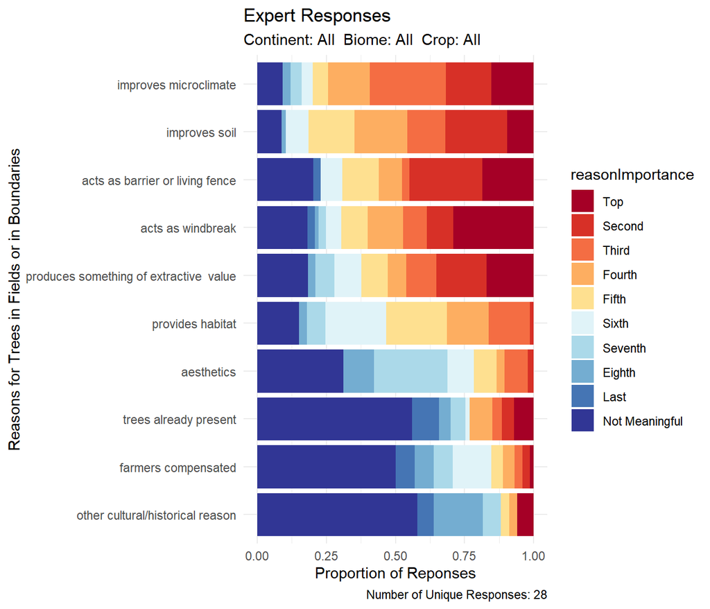

```r
#initialize defaults
what2plot<-"Reasons for Trees in Fields or in Boundaries"
continent<-"All"
biome<-"All"


crop_histogram(crop="All",data=policy_long,what2plot=what2plot,continent=continent,biome=biome)
```

2. Display plot for Corn

```
##                                     reason sum.b sum.f  rank
## 1                                    Other    63     0  63.0
## 2         other cultural/historical reason     0   156 156.0
## 3                    trees already present    91   242 166.5
## 4                      farmers compensated   137   222 179.5
## 5                               aesthetics   200   204 202.0
## 6                         provides habitat   366   378 372.0
## 7  produces something of extractive  value   543   360 451.5
## 8                        acts as windbreak   420   508 464.0
## 9          acts as barrier or living fence   504     0 504.0
## 10                           improves soil   540   554 547.0
## 11                   improves microclimate   540   567 553.5
```

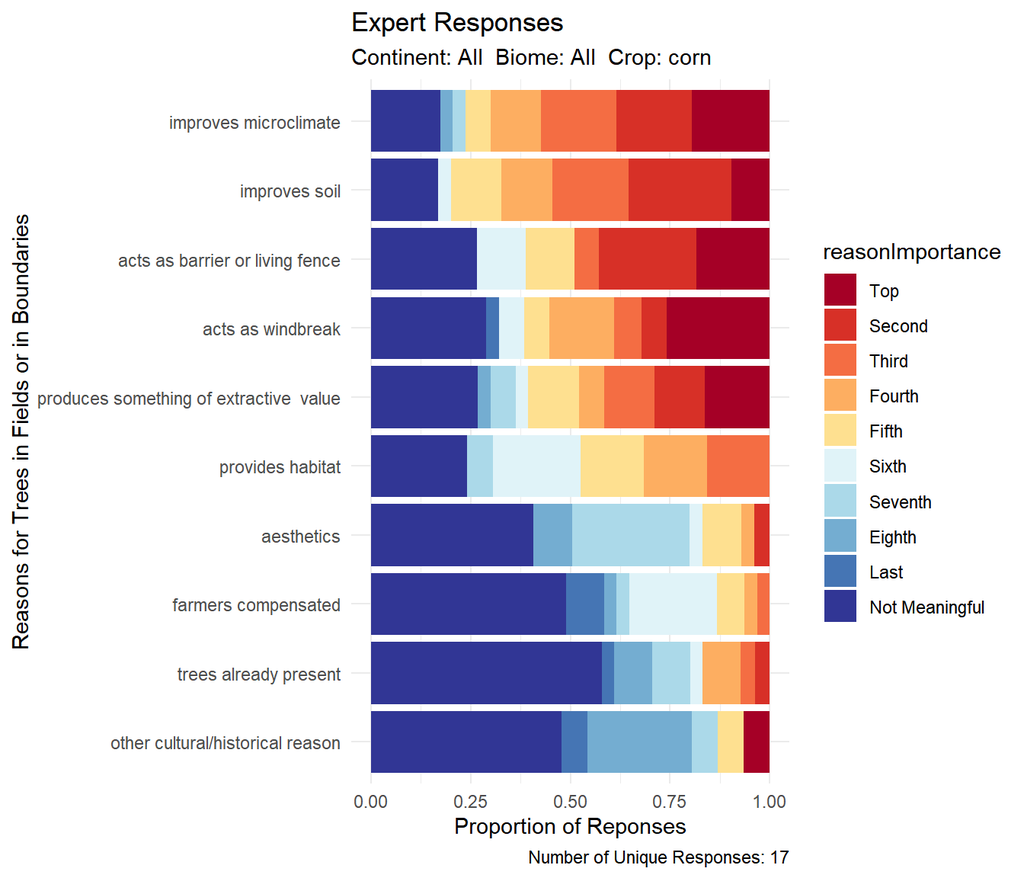

```r
crop_histogram(crop="corn",data=policy_long,what2plot=what2plot,continent=continent,biome=biome)
```

3. Display plot for Wheat

```
##                                     reason sum.b sum.f  rank
## 1         other cultural/historical reason     0    51  51.0
## 2                                    Other     0    54  54.0
## 3                      farmers compensated   132   198 165.0
## 4                    trees already present   175   297 236.0
## 5                               aesthetics   233   313 273.0
## 6                         provides habitat   383   412 397.5
## 7  produces something of extractive  value   535   514 524.5
## 8          acts as barrier or living fence   528     0 528.0
## 9                            improves soil   494   569 531.5
## 10                   improves microclimate   543   619 581.0
## 11                       acts as windbreak   541   639 590.0
```

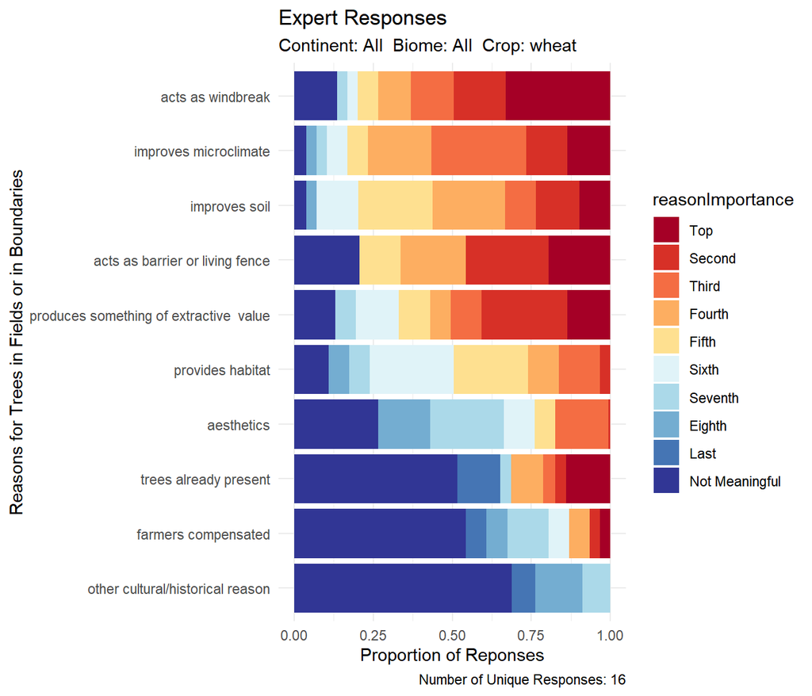

```r
crop_histogram(crop="wheat",data=policy_long,what2plot=what2plot,continent=continent,biome=biome)
```

2. Display plot for Soy

```
##                                     reason sum.b sum.f  rank
## 1                    trees already present    67    54  60.5
## 2                      farmers compensated    60   108  84.0
## 3         other cultural/historical reason     0    90  90.0
## 4                               aesthetics   140   102 121.0
## 5                        acts as windbreak   180   174 177.0
## 6                         provides habitat   180   174 177.0
## 7  produces something of extractive  value   237   138 187.5
## 8          acts as barrier or living fence   210     0 210.0
## 9                    improves microclimate   240   198 219.0
## 10                           improves soil   246   204 225.0
```

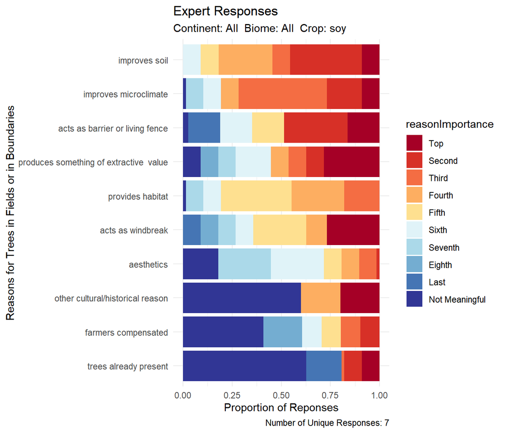

```r
crop_histogram(crop="soy",data=policy_long,what2plot=what2plot,continent=continent,biome=biome)
```

# 7 Questions and Next Steps

## 7.1 Graphing options

1. At your request I can add other user inputs (for different combinations of biome, continent, policy recommendations/reasons for fields/reasons for boundaries)
2. I can also export plots from R as jpegs.
3. Colors, style, etc are mutable.
4. We can make other kinds of graphs: pie charts, side-by-side bar charts, and more.

## 7.2 I have three data questions:

1. How do you want to handle the rare instances where experts typed in their own “reason” or “policy recommendation”
- Exclude these from quantitative analysis but mention them in discussion
- Choose the reason that is most closely connected to the reason they describe, but mention their nuance in the discussion
2. One expert (Pierluigi) filled out the questionnaire three times, each for a unique representative tree. How do you want to handle this?
- keep just one of Pierluigi’s responses, so that the “unique responses” are just “one per expert”
- expand all representative tree species columns for every expert, and treat them as having a unique (though duplicated) response for each tree
- do nothing, allow Pierluigi to have contributed three unique responses
3. Do you consider it ever meaningful to combine “reasons trees in boundaries” and “reasons trees in fields” for comparison between continent-biome pairs?
- I did so in this document just to demonstrate
- it’s also possible to keep these totally separate
- it’s slightly misleading to combine them, because only 8/9 of the options overlapped.